# TP : SVM et Classe déséquilibrées

Aymane Mimoun

2024-04-22

# Introduction

Dans ce projet, nous abordons un défi commun en apprentissage automatique : le problème de classe déséquilibrée. Nous nous concentrons spécifiquement sur l’application de l’algorithme SVM (Support Vector Machine) à la détection de fraudes, un domaine où le déséquilibre de classe est souvent rencontré.

La variable de classe est transformée en facteur pour représenter les classes “fraude” et “non-fraude”.

```r
head(df)
```

```
##   Time         V1          V2        V3         V4          V5          V6
## 1    0 -1.3598071 -0.07278117 2.5363467  1.3781552 -0.33832077  0.46238778
## 2    0  1.1918571  0.26615071 0.1664801  0.4481541  0.06001765 -0.08236081
## 3    1 -1.3583541 -1.34016307 1.7732093  0.3797796 -0.50319813  1.80049938
## 4    1 -0.9662717 -0.18522601 1.7929933 -0.8632913 -0.01030888  1.24720317
## 5    2 -1.1582331  0.87773675 1.5487178  0.4030339 -0.40719338  0.09592146
## 6    2 -0.4259659  0.96052304 1.1411093 -0.1682521  0.42098688 -0.02972755
##            V7          V8         V9         V10        V11         V12
## 1  0.23959855  0.09869790  0.3637870  0.09079417 -0.5515995 -0.61780086
## 2 -0.07880298  0.08510165 -0.2554251 -0.16697441  1.6127267  1.06523531
## 3  0.79146096  0.24767579 -1.5146543  0.20764287  0.6245015  0.06608369
## 4  0.23760894  0.37743587 -1.3870241 -0.05495192 -0.2264873  0.17822823
## 5  0.59294075 -0.27053268  0.8177393  0.75307443 -0.8228429  0.53819555
## 6  0.47620095  0.26031433 -0.5686714 -0.37140720  1.3412620  0.35989384
##          V13        V14        V15        V16         V17         V18
```

[output cut: 20 more lines]

```r
df$Class <- as.factor(df$Class)
X<-df[, paste0("V", 1:28)]
y<-df$Class
table(y)
```

```
## y
##     0     1
## 19915    85
```

```r
summary(y)
```

```
##     0     1
## 19915    85
```

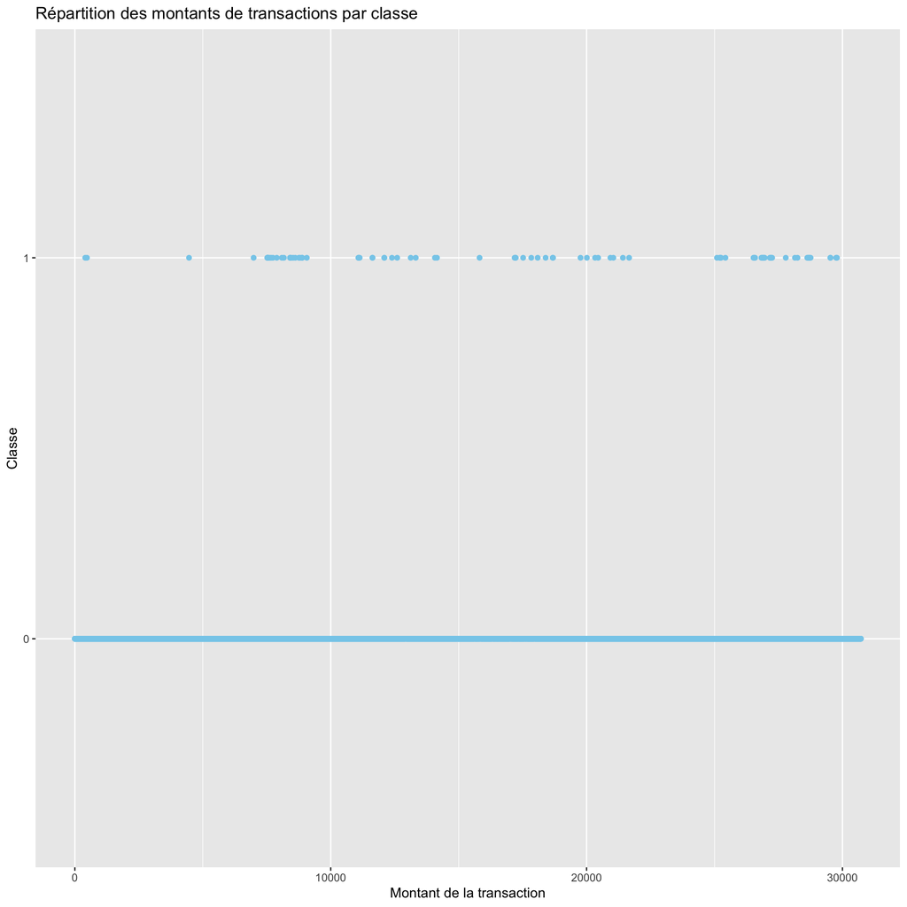

```r
ggplot(data = df, aes(x = Time, y = Class)) +
  geom_point(color = "skyblue") +
  labs(x = "Montant de la transaction", y = "Classe", title = "Répartition des montants de transactions par classe")
```

Une inspection préliminaire des données révèle un déséquilibre marqué entre les classes, avec une grande majorité de transactions légitimes par rapport aux fraudes.

# Un jeu de données déséquilibré

Ensuite, les données sont divisées en ensembles d’entraînement et de test. Un modèle SVM est entraîné sur les données d’entraînement initiales.

```r
set.seed(12345)
train_indices <- createDataPartition(df$Class, p = 0.8, list = FALSE)

# Séparer les données en ensembles d'entraînement et de test
X_train <- df[train_indices, -which(names(df) == "Class")]
y_train <- df[train_indices, "Class"]
X_test <- df[-train_indices, -which(names(df) == "Class")]
y_test <- df[-train_indices, "Class"]

model <- svm(Class ~ ., data = df[train_indices, ], kernel = "radial")
model
```

```
##
## Call:
## svm(formula = Class ~ ., data = df[train_indices, ], kernel = "radial")
##
##
## Parameters:
##    SVM-Type:  C-classification
##  SVM-Kernel:  radial
##        cost:  1
##
## Number of Support Vectors:  506
```

Les prédictions sont effectuées sur l’ensemble de test et la performance du modèle est évaluée à l’aide d’une matrice de confusion.

```r
predictions <- predict(model, newdata = X_test)
mat <- confusionMatrix(predictions, y_test)
mat
```

```
## Confusion Matrix and Statistics
##
##           Reference
## Prediction    0    1
##          0 3983    4
##          1    0   13
##
##                Accuracy : 0.999
##                  95% CI : (0.9974, 0.9997)
##     No Information Rate : 0.9958
##     P-Value [Acc > NIR] : 0.0001807
##
##                   Kappa : 0.8662
##
##  Mcnemar's Test P-Value : 0.1336144
##
##             Sensitivity : 1.0000
##             Specificity : 0.7647
##          Pos Pred Value : 0.9990
##          Neg Pred Value : 1.0000
##              Prevalence : 0.9958
##          Detection Rate : 0.9958
##    Detection Prevalence : 0.9968
##       Balanced Accuracy : 0.8824
##
##        'Positive' Class : 0
##
```

Nous constatons que notre modèle a du mal à détecter les fraudes, avec un nombre significatif de transactions frauduleuses classées à tort comme légitimes.

On a 25% de de transaction frauduleuse classé comme légale, ce qui est très contraignant.

# Explication théorique

On peut observer le déséquilibre de classe en observant les probabilités liées à chaque classe dans un ensemble de données.

Supposons que nous ayons un problème de classification binaire avec deux classes, positif (1) et négatif (0). Soit $P(Y=1)$ la probabilité d’observation d’un exemple de la classe positive, et $P(Y=0)$ la probabilité d’observation d’un exemple de la classe négative. Dans un ensemble de données équilibré, ces probabilités seraient égales ou similaires, c’est-à-dire que $P(Y=1)\approx P(Y=0)$

En présence d’un déséquilibre de classe, une classe peut être beaucoup plus fréquente que l’autre, ce qui implique que $P(Y=1)$ et $P(Y=0)$ sont très différents.

Les algorithmes de classification sont confrontés à ce problème, car ils sont souvent influencés par la fréquence des classes lors de leur apprentissage. La plupart du temps, si une classe est beaucoup plus répandue que l’autre, le modèle peut avoir tendance à prédire cette classe majoritaire, ignorant ainsi la classe minoritaire.

Une explication plus quantitative :

Le modèle va avoir tendance à prédire la classe majoritaire, on a donc un classifieur qui retournera toujours la classe majoritaire. Notons là la N-ème.

Alors la probabilité : $ P(Y=y, c(X)=N)=P(Y=y)$ et donc le risque du déséquilibre se note : $R=\sum_{y=1}^{N}l(y, N)P(Y=y, c(X)=N)=\sum_{y=1}^{N}l(y, N)P(Y=y) \\ =\sum_{y=1}^{N} 1_{y\neq N}P(Y=y)=1-P(Y=N)$

# Solutions

## Réequilibrage des données : sur-échantillonage

Pour résoudre le problème de déséquilibre de classe, une technique de suréchantillonnage est utilisée avec la fonction ROSE.

```r
df_balanced <- ROSE::ROSE(Class ~ ., data = df[train_indices, ], seed = 12345)$data


table(df_balanced$Class)
```

```
##
##    0    1
## 7990 8010
```

```r
train_indices_balanced <- createDataPartition(df_balanced$Class, p = 0.8, list = FALSE)

X_train_balanced <- df_balanced[train_indices_balanced, -which(names(df_balanced) == "Class")]
y_train_balanced <- df_balanced[train_indices_balanced, "Class"]
X_test_balanced <- df_balanced[-train_indices_balanced, -which(names(df_balanced) == "Class")]
y_test_balanced <- df_balanced[-train_indices_balanced, "Class"]
```

Le sur-échantillonage nous permet de rééquilibré les classes, les fraudes représente maintenant environ 50% des classes.

On le verifie graphiquement :

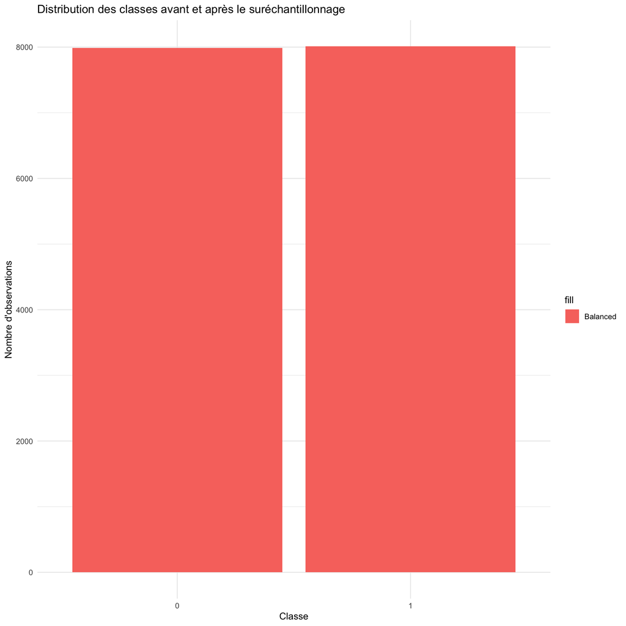

```r
ggplot() +
  geom_bar(data = df_balanced, aes(x = Class, fill = "Balanced"), position = "dodge") +
  labs(title = "Distribution des classes avant et après le suréchantillonnage",
       x = "Classe",
       y = "Nombre d'observations") +
  theme_minimal()
```

Un nouveau modèle SVM est entraîné sur les données équilibrées. Les prédictions sont effectuées sur l’ensemble de test équilibré et la performance est évaluée.

```r
new_model <- svm(Class ~ ., data = df_balanced[train_indices_balanced, ], kernel = "radial")

new_predictions <- predict(new_model, newdata = X_test_balanced)
mat <- confusionMatrix(new_predictions, y_test_balanced)
mat
```

```
## Confusion Matrix and Statistics
##
##           Reference
## Prediction    0    1
##          0 1584   17
##          1   14 1585
##
##                Accuracy : 0.9903
##                  95% CI : (0.9863, 0.9934)
##     No Information Rate : 0.5006
##     P-Value [Acc > NIR] : <2e-16
##
##                   Kappa : 0.9806
##
##  Mcnemar's Test P-Value : 0.7194
##
##             Sensitivity : 0.9912
##             Specificity : 0.9894
##          Pos Pred Value : 0.9894
##          Neg Pred Value : 0.9912
##              Prevalence : 0.4994
##          Detection Rate : 0.4950
##    Detection Prevalence : 0.5003
##       Balanced Accuracy : 0.9903
##
##        'Positive' Class : 0
##
```

On remarque que l’on passe de 25% erreurs, à 1% d’erreur, ce qui est nettement plus precis. On remarque qu’il y a aussi plus de transaction légale classé en fraude, ce qui n’est pas si derangant que ca, car ce qui nous interesse sont les fraudes

## Rééquilibrage par pondération

Un autre modèle SVM est entraîné en utilisant la pondération de classe pour traiter le déséquilibre.

```r
model_final<-svm(Class ~ ., data = df_balanced[train_indices_balanced, ],
                      kernel = "radial",
                      class.weights = c("0" = 1, "1" = 2))

predictions_final<-predict(model_final, newdata = X_test_balanced)
mat_final<-confusionMatrix(predictions_final, y_test_balanced)
mat_final
```

```
## Confusion Matrix and Statistics
##
##           Reference
## Prediction    0    1
##          0 1583   10
##          1   15 1592
##
##                Accuracy : 0.9922
##                  95% CI : (0.9885, 0.9949)
##     No Information Rate : 0.5006
##     P-Value [Acc > NIR] : <2e-16
##
##                   Kappa : 0.9844
##
##  Mcnemar's Test P-Value : 0.4237
##
##             Sensitivity : 0.9906
##             Specificity : 0.9938
##          Pos Pred Value : 0.9937
##          Neg Pred Value : 0.9907
##              Prevalence : 0.4994
##          Detection Rate : 0.4947
##    Detection Prevalence : 0.4978
##       Balanced Accuracy : 0.9922
##
##        'Positive' Class : 0
##
```

Après avoir ajouté un poids de 2 pour la classe “fraude”, nous avons observé une amélioration des performances du modèle.

## Validation croisée

Enfin, une validation croisée est effectuée pour sélectionner le meilleur modèle SVM.

```r
# Entraînement du modèle SVM avec validation croisée
model_cv <- train(Class ~ ., data = df_balanced[train_indices_balanced, ],
                  method = "svmRadial",
                  trControl = trainControl(method = "cv", number = 5),
                  class.weights = c("0" = 1, "1" = 2))

# Affichage des résultats de la validation croisée
print(model_cv)
```

```
## Support Vector Machines with Radial Basis Function Kernel
##
## 12800 samples
##    30 predictor
##     2 classes: '0', '1'
##
## No pre-processing
## Resampling: Cross-Validated (5 fold)
## Summary of sample sizes: 10240, 10240, 10240, 10240, 10240
## Resampling results across tuning parameters:
##
##   C     Accuracy   Kappa
##   0.25  0.9890625  0.9781248
##   0.50  0.9913281  0.9826562
##   1.00  0.9925781  0.9851562
##
## Tuning parameter 'sigma' was held constant at a value of 0.03541963
## Accuracy was used to select the optimal model using the largest value.
## The final values used for the model were sigma = 0.03541963 and C = 1.
```

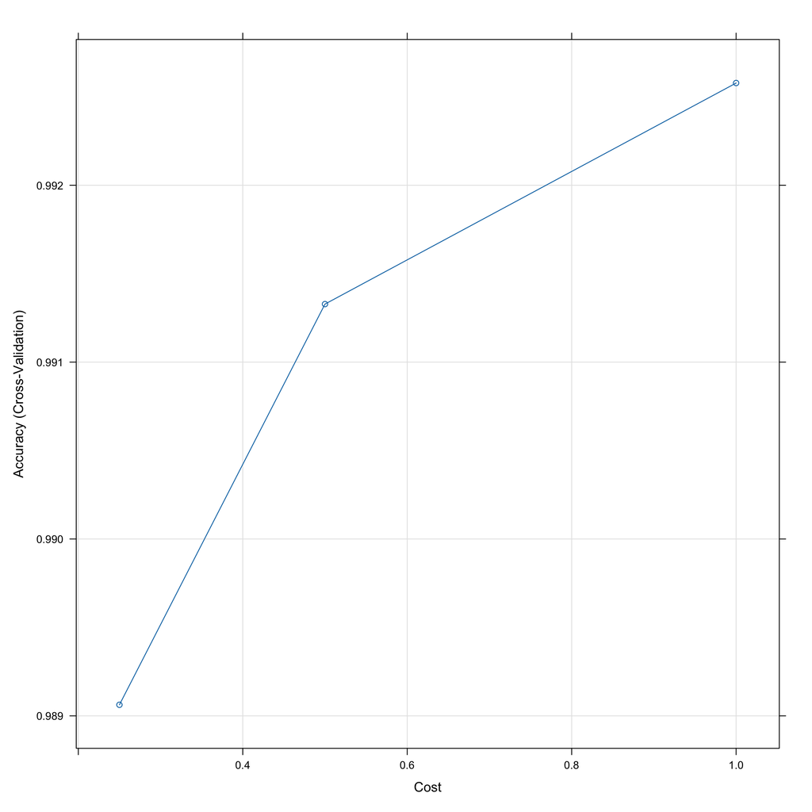

```r
# Visualisation des performances
plot(model_cv)
```

Le coût optimal a été déterminé graphiquement à l’aide de la validation croisée, et nous avons constaté que le modèle avec un coût de 1 présentait les meilleures performances.

# Conclusion

ce projet souligne l’importance de la gestion du déséquilibre de classe dans Machine Learning. En reconnaissant ce problème et en explorant des solutions appropriées, nous pouvons développer des modèles de classification plus robustes et plus efficaces.

# References

https://www.kaggle.com/datasets/mlg-ulb/creditcardfraud \ Apprentissage statistique Classification supervisée, Vincent Runge, (2024) \ https://lrouviere.github.io/INP-HB/cours_don_des.pdf \ https://towardsdatascience.com/the-complete-guide-to-support-vector-machine-svm-f1a820d8af0b